# SHRS National Employment Analysis

gpps

2026-02-13

# 0 — Configuration

**To run this for a different year**: change `DATA_FILE` and `DATA_YEAR` below. Everything else adapts automatically.

```r
# ══════════════════════════════════════════════════════════════════════════════
# CHANGE THESE TWO LINES FOR EACH YEAR — everything else adapts automatically
# ══════════════════════════════════════════════════════════════════════════════
DATA_FILE <- '/Users/gpps/Documents/SHRS_Analysis/market_analysis/v3data/national_employment_by_year_csv/national_M2023_dl - national_M2023_dl.csv'
DATA_YEAR <- 2023
# ══════════════════════════════════════════════════════════════════════════════

# ── SOC crosswalk — all 9 SHRS programs (stable across years) ──
soc_crosswalk <- tibble::tribble(
  ~shrs_program, ~shrs_dept, ~soc_code,  ~occupation_title,              ~pitt_degree,
  "SLP",         "CSD",      "29-1127",  "Speech-Language Pathologists",  "Master's",
  "AuD",         "CSD",      "29-1181",  "Audiologists",                  "Doctoral",
  "HIM",         "HIM",      "29-9021",  "Health Information Technologists and Medical Registrars", "Master's",
  "OTD",         "OT",       "29-1122",  "Occupational Therapists",       "Doctoral",
  "DPT",         "PT",       "29-1123",  "Physical Therapists",           "Doctoral",
  "PAS",         "PAS",      "29-1071",  "Physician Assistants",          "Master's",
  "AT",          "SMN",      "29-9091",  "Athletic Trainers",             "Master's",
  "DN",          "SMN",      "29-1031",  "Dietitians and Nutritionists",  "Master's",
  "SS",          "SMN",      "29-1128",  "Exercise Physiologists",        "Master's"
)

# Benchmark SOC codes
BENCHMARK_ALL_OCC   <- "00-0000"
BENCHMARK_HC_MAJOR  <- "29-0000"

# ── COLOR SYSTEM ──
# Health performance: Red (poor) / Yellow (moderate) / Green (strong)
# Statistical / neutral visuals: Blue
COL_GREEN  <- "#27ae60"
COL_YELLOW <- "#f39c12"
COL_RED    <- "#e74c3c"
COL_BLUE   <- "#2980b9"
COL_BLUE_LIGHT <- "#85c1e9"
COL_GRAY   <- "#95a5a6"

# Health performance scale (for filled bars, tiles, etc.)
health_colors <- c("Strong" = COL_GREEN, "Moderate" = COL_YELLOW, "Weak" = COL_RED)

# Precision scale (green = good precision, red = poor precision)
precision_colors <- c("High Precision" = COL_GREEN, "Moderate" = COL_YELLOW, "Low Precision" = COL_RED)

# ── SOC legacy mapping for older OEWS vintages ──
# The 2018 SOC revision changed some codes. If running on pre-2019 files
# and a program shows as missing, you may need to use these legacy codes:
#   HIM: 29-2071 (Medical Records and Health Information Technicians) → now 29-9021
#   PAS: 29-1071 (unchanged)
#   SS:  29-1128 (may not exist before ~2018; lumped into broader groups)
# The crosswalk above uses current (2018+) SOC codes.
```

```r
library(tidyverse)
library(scales)
library(kableExtra)
```

# 1 — Load & Clean Data

```r
raw <- read_csv(DATA_FILE, show_col_types = FALSE)
cat("Loaded", nrow(raw), "rows,", ncol(raw), "columns\n")
```

```
## Loaded 1403 rows, 20 columns
```

```r
cat("Columns:", paste(names(raw), collapse = ", "), "\n")
```

```
## Columns: OCC_CODE, OCC_TITLE, OCC_GROUP, TOT_EMP, EMP_PRSE, H_MEAN, A_MEAN, MEAN_PRSE, H_PCT10, H_PCT25, H_MEDIAN, H_PCT75, H_PCT90, A_PCT10, A_PCT25, A_MEDIAN, A_PCT75, A_PCT90, ANNUAL, HOURLY
```

```r
# Helper: clean BLS numeric fields (remove commas, convert suppressed values to NA)
clean_bls_num <- function(x) {
  x <- as.character(x)
  x <- str_remove_all(x, ",")
  x <- if_else(x %in% c("*", "**", "#", "\u2014", "--", "N/A", ""), NA_character_, x)
  as.numeric(x)
}

# Clean the full dataset
oews <- raw %>%
  mutate(
    year      = DATA_YEAR,
    tot_emp   = clean_bls_num(TOT_EMP),
    emp_prse  = clean_bls_num(EMP_PRSE),
    a_mean    = clean_bls_num(A_MEAN),
    a_median  = clean_bls_num(A_MEDIAN),
    a_pct10   = clean_bls_num(A_PCT10),
    a_pct25   = clean_bls_num(A_PCT25),
    a_pct75   = clean_bls_num(A_PCT75),
    a_pct90   = clean_bls_num(A_PCT90),
    h_mean    = clean_bls_num(H_MEAN),
    h_median  = clean_bls_num(H_MEDIAN),
    mean_prse = clean_bls_num(MEAN_PRSE)
  ) %>%
  select(year, occ_code = OCC_CODE, occ_title = OCC_TITLE, occ_group = OCC_GROUP,
         tot_emp, emp_prse, a_mean, a_median, a_pct10, a_pct25, a_pct75, a_pct90,
         h_mean, h_median, mean_prse)

# Extract benchmarks
bench_all <- oews %>% filter(occ_code == BENCHMARK_ALL_OCC)
bench_hc  <- oews %>% filter(occ_code == BENCHMARK_HC_MAJOR)

# Extract SHRS programs
shrs <- oews %>%
  filter(occ_code %in% soc_crosswalk$soc_code) %>%
  left_join(soc_crosswalk, by = c("occ_code" = "soc_code")) %>%
  select(year, shrs_program, shrs_dept, pitt_degree, occ_code,
         occ_title = occupation_title,
         tot_emp, emp_prse, a_mean, a_median,
         a_pct10, a_pct25, a_pct75, a_pct90,
         h_mean, h_median, mean_prse)

cat("\n\u2500\u2500 SHRS programs found:", nrow(shrs), "of", nrow(soc_crosswalk), "expected \u2500\u2500\n")
```

```
##
## ── SHRS programs found: 9 of 9 expected ──
```

```r
if (nrow(shrs) < nrow(soc_crosswalk)) {
  missing <- setdiff(soc_crosswalk$soc_code, shrs$occ_code)
  cat("MISSING SOC codes:", paste(missing, collapse = ", "), "\n")
}
```

# 2 — Employment Overview

## 2.1 Employment Levels

```r
emp_summary <- shrs %>%
  select(shrs_program, occ_title, tot_emp, emp_prse) %>%
  bind_rows(
    tibble(shrs_program = "All Occupations",
           occ_title = "All Occupations",
           tot_emp = bench_all$tot_emp, emp_prse = bench_all$emp_prse),
    tibble(shrs_program = "Healthcare (29-0000)",
           occ_title = "Healthcare Practitioners & Technical",
           tot_emp = bench_hc$tot_emp, emp_prse = bench_hc$emp_prse)
  ) %>%
  mutate(
    pct_of_all_occ = round(tot_emp / bench_all$tot_emp * 100, 4),
    pct_of_hc      = round(tot_emp / bench_hc$tot_emp * 100, 2)
  )

emp_summary %>%
  select(Program = shrs_program, Occupation = occ_title,
         `Total Emp` = tot_emp, `Emp PRSE (%)` = emp_prse,
         `% of All Occ` = pct_of_all_occ, `% of HC Sector` = pct_of_hc) %>%
  kable(format.args = list(big.mark = ","), digits = 3) %>%
  kable_styling(bootstrap_options = c("striped", "hover"), full_width = FALSE)
```

| Program | Occupation | Total Emp | Emp PRSE (%) | % of All Occ | % of HC Sector |
| --- | --- | --- | --- | --- | --- |
| DN | Dietitians and Nutritionists | 73,860 | 1.9 | 0.049 | 0.80 |
| PAS | Physician Assistants | 145,740 | 1.7 | 0.096 | 1.57 |
| OTD | Occupational Therapists | 144,840 | 1.1 | 0.095 | 1.56 |
| DPT | Physical Therapists | 240,820 | 1.3 | 0.159 | 2.59 |
| SLP | Speech-Language Pathologists | 172,100 | 1.1 | 0.113 | 1.85 |
| SS | Exercise Physiologists | 8,060 | 5.6 | 0.005 | 0.09 |
| AuD | Audiologists | 13,880 | 4.4 | 0.009 | 0.15 |
| HIM | Health Information Technologists and Medical Registrars | 34,430 | 1.4 | 0.023 | 0.37 |
| AT | Athletic Trainers | 28,480 | 2.1 | 0.019 | 0.31 |
| All Occupations | All Occupations | 151,853,870 | 0.0 | 100.000 | 1,635.61 |
| Healthcare (29-0000) | Healthcare Practitioners & Technical | 9,284,210 | 0.1 | 6.114 | 100.00 |

## 2.2 Employment Bar Chart

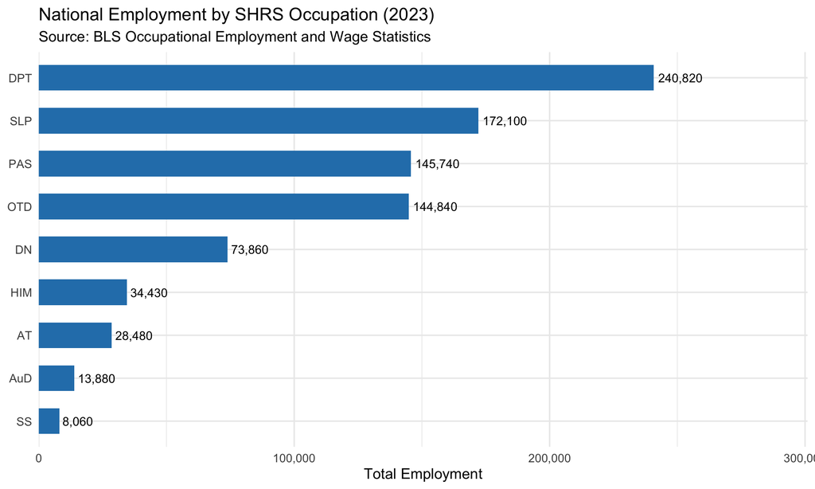

```r
shrs %>%
  ggplot(aes(x = reorder(shrs_program, tot_emp), y = tot_emp)) +
  geom_col(width = 0.6, fill = COL_BLUE) +
  geom_text(aes(label = comma(tot_emp)), hjust = -0.1, size = 3.8) +
  coord_flip() +
  scale_y_continuous(labels = comma, expand = expansion(mult = c(0, 0.25))) +
  labs(
    title    = paste0("National Employment by SHRS Occupation (", DATA_YEAR, ")"),
    subtitle = "Source: BLS Occupational Employment and Wage Statistics",
    x = NULL, y = "Total Employment"
  ) +
  theme_minimal(base_size = 13) +
  theme(legend.position = "none")
```

## 2.3 Market Size Context

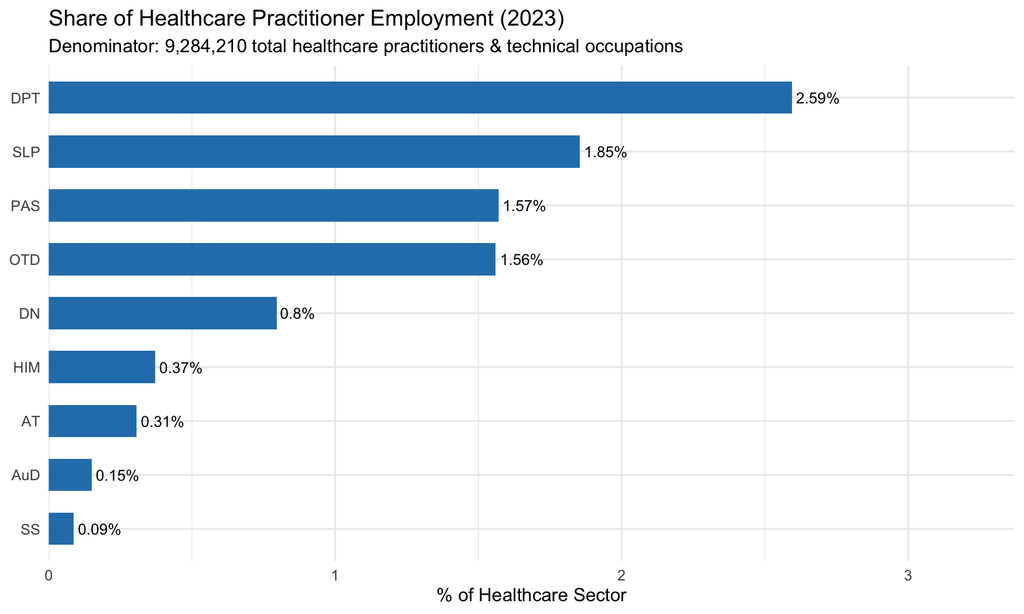

```r
shrs %>%
  mutate(pct_hc = tot_emp / bench_hc$tot_emp * 100) %>%
  ggplot(aes(x = reorder(shrs_program, pct_hc), y = pct_hc)) +
  geom_col(width = 0.6, fill = COL_BLUE) +
  geom_text(aes(label = paste0(round(pct_hc, 2), "%")), hjust = -0.1, size = 3.8) +
  coord_flip() +
  scale_y_continuous(expand = expansion(mult = c(0, 0.3))) +
  labs(
    title    = paste0("Share of Healthcare Practitioner Employment (", DATA_YEAR, ")"),
    subtitle = paste0("Denominator: ", comma(bench_hc$tot_emp),
                      " total healthcare practitioners & technical occupations"),
    x = NULL, y = "% of Healthcare Sector"
  ) +
  theme_minimal(base_size = 13)
```

# 3 — Wage Analysis

## 3.1 Wage Distribution Summary

```r
wage_summary <- shrs %>%
  select(shrs_program, a_pct10, a_pct25, a_median, a_pct75, a_pct90, a_mean) %>%
  bind_rows(
    tibble(shrs_program = "All Occupations",
           a_pct10 = bench_all$a_pct10, a_pct25 = bench_all$a_pct25,
           a_median = bench_all$a_median, a_pct75 = bench_all$a_pct75,
           a_pct90 = bench_all$a_pct90, a_mean = bench_all$a_mean),
    tibble(shrs_program = "Healthcare (29-0000)",
           a_pct10 = bench_hc$a_pct10, a_pct25 = bench_hc$a_pct25,
           a_median = bench_hc$a_median, a_pct75 = bench_hc$a_pct75,
           a_pct90 = bench_hc$a_pct90, a_mean = bench_hc$a_mean)
  ) %>%
  mutate(
    iqr         = a_pct75 - a_pct25,
    wage_spread = a_pct90 - a_pct10,
    skew_ratio  = round((a_mean - a_median) / a_median * 100, 1),
    median_ratio_vs_all = round(a_median / bench_all$a_median, 2)
  )

wage_summary %>%
  select(Program = shrs_program, P10 = a_pct10, P25 = a_pct25,
         Median = a_median, P75 = a_pct75, P90 = a_pct90, Mean = a_mean,
         IQR = iqr, `90-10 Spread` = wage_spread,
         `Mean-Med Skew (%)` = skew_ratio, `vs All Occ` = median_ratio_vs_all) %>%
  kable(format.args = list(big.mark = ",")) %>%
  kable_styling(bootstrap_options = c("striped", "hover"), full_width = FALSE)
```

| Program | P10 | P25 | Median | P75 | P90 | Mean | IQR | 90-10 Spread | Mean-Med Skew (%) | vs All Occ |
| --- | --- | --- | --- | --- | --- | --- | --- | --- | --- | --- |
| DN | 44,910 | 58,290 | 69,680 | 81,860 | 98,830 | 71,280 | 23,570 | 53,920 | 2.3 | 1.45 |
| PAS | 86,280 | 108,100 | 130,020 | 151,720 | 170,790 | 130,490 | 43,620 | 84,510 | 0.4 | 2.71 |
| OTD | 65,210 | 79,290 | 96,370 | 109,480 | 129,620 | 96,790 | 30,190 | 64,410 | 0.4 | 2.01 |
| DPT | 72,260 | 81,970 | 99,710 | 113,630 | 130,870 | 100,440 | 31,660 | 58,610 | 0.7 | 2.07 |
| SLP | 57,910 | 71,140 | 89,290 | 107,710 | 129,930 | 92,630 | 36,570 | 72,020 | 3.7 | 1.86 |
| SS | 35,460 | 45,870 | 54,860 | 64,110 | 77,680 | 57,050 | 18,240 | 42,220 | 4.0 | 1.14 |
| AuD | 56,090 | 74,440 | 87,740 | 105,480 | 124,800 | 92,620 | 31,040 | 68,710 | 5.6 | 1.83 |
| HIM | 38,310 | 46,580 | 62,990 | 86,950 | 107,650 | 70,260 | 40,370 | 69,340 | 11.5 | 1.31 |
| AT | 43,180 | 49,750 | 57,930 | 66,580 | 80,640 | 61,540 | 16,830 | 37,460 | 6.2 | 1.21 |
| All Occupations | 29,050 | 35,660 | 48,060 | 76,980 | 121,470 | 65,470 | 41,320 | 92,420 | 36.2 | 1.00 |
| Healthcare (29-0000) | 41,350 | 59,700 | 80,820 | 111,240 | 167,320 | 102,060 | 51,540 | 125,970 | 26.3 | 1.68 |

## 3.2 Wage Distribution Visualization

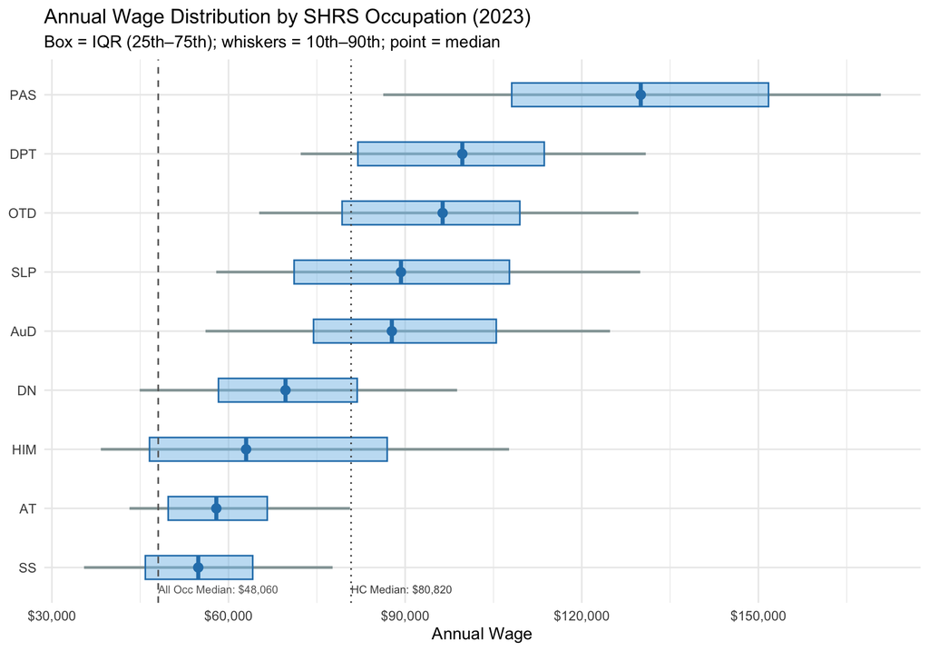

```r
shrs %>%
  ggplot(aes(x = reorder(shrs_program, a_median))) +
  geom_linerange(aes(ymin = a_pct10, ymax = a_pct90),
                 linewidth = 1, color = COL_GRAY) +
  geom_crossbar(aes(y = a_median, ymin = a_pct25, ymax = a_pct75),
                width = 0.4, fill = COL_BLUE_LIGHT, alpha = 0.5,
                color = COL_BLUE) +
  geom_point(aes(y = a_median), size = 3, color = COL_BLUE) +
  geom_hline(yintercept = bench_all$a_median, linetype = "dashed",
             color = "gray40", linewidth = 0.6) +
  annotate("text", x = 0.5, y = bench_all$a_median,
           label = paste0("All Occ Median: ", dollar(bench_all$a_median)),
           hjust = 0, vjust = -0.5, size = 3, color = "gray40") +
  geom_hline(yintercept = bench_hc$a_median, linetype = "dotted",
             color = "gray30", linewidth = 0.6) +
  annotate("text", x = 0.5, y = bench_hc$a_median,
           label = paste0("HC Median: ", dollar(bench_hc$a_median)),
           hjust = 0, vjust = -0.5, size = 3, color = "gray30") +
  coord_flip() +
  scale_y_continuous(labels = dollar) +
  labs(
    title    = paste0("Annual Wage Distribution by SHRS Occupation (", DATA_YEAR, ")"),
    subtitle = "Box = IQR (25th\u201375th); whiskers = 10th\u201390th; point = median",
    x = NULL, y = "Annual Wage"
  ) +
  theme_minimal(base_size = 13)
```

## 3.3 Wage Premium — Health Performance

Color indicates health: green (strong premium), yellow (near benchmark), red (below benchmark).

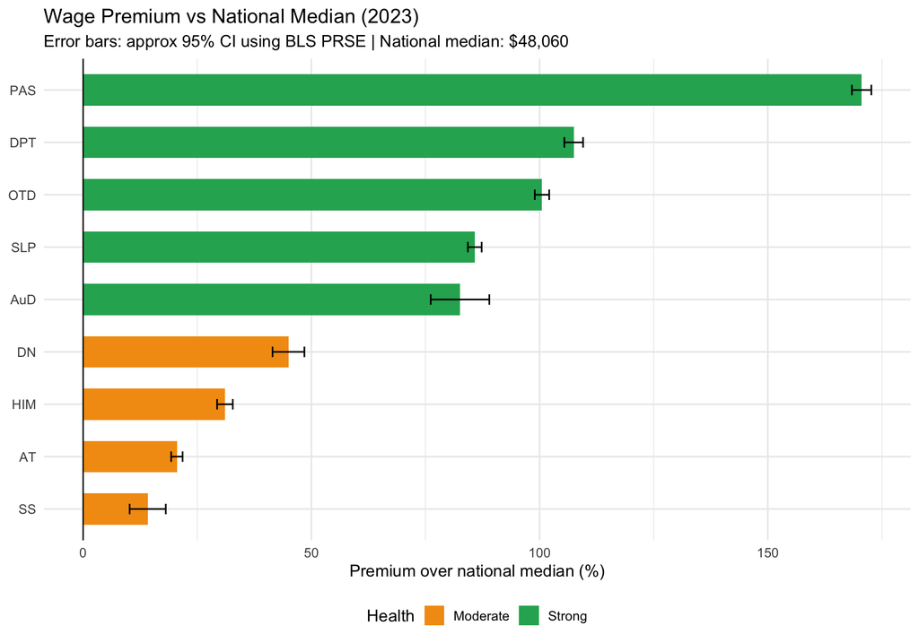

```r
wage_premium <- shrs %>%
  mutate(
    premium_pct = (a_median - bench_all$a_median) / bench_all$a_median * 100,
    wage_se     = a_mean * (mean_prse / 100),
    ci_lower    = a_median - 1.96 * wage_se,
    ci_upper    = a_median + 1.96 * wage_se,
    prem_lower  = (ci_lower - bench_all$a_median) / bench_all$a_median * 100,
    prem_upper  = (ci_upper - bench_all$a_median) / bench_all$a_median * 100,
    health = case_when(
      premium_pct >= 50  ~ "Strong",
      premium_pct >= 0   ~ "Moderate",
      TRUE               ~ "Weak"
    )
  )

wage_premium %>%
  ggplot(aes(x = reorder(shrs_program, premium_pct), y = premium_pct,
             fill = health)) +
  geom_col(width = 0.6) +
  geom_errorbar(aes(ymin = prem_lower, ymax = prem_upper),
                width = 0.2, linewidth = 0.6) +
  geom_hline(yintercept = 0, linewidth = 0.5) +
  coord_flip() +
  scale_fill_manual(values = health_colors, name = "Health") +
  labs(
    title    = paste0("Wage Premium vs National Median (", DATA_YEAR, ")"),
    subtitle = paste0("Error bars: approx 95% CI using BLS PRSE | ",
                      "National median: ", dollar(bench_all$a_median)),
    x = NULL, y = "Premium over national median (%)"
  ) +
  theme_minimal(base_size = 13) +
  theme(legend.position = "bottom")
```

## 3.4 Wage Dispersion (IQR)

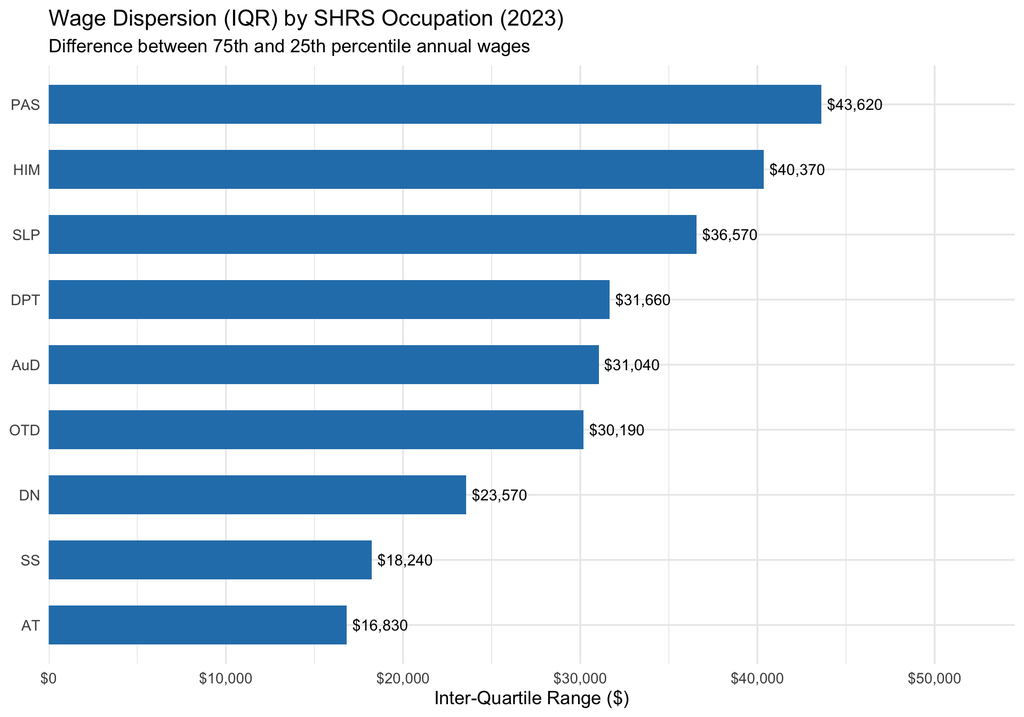

```r
shrs %>%
  mutate(iqr = a_pct75 - a_pct25) %>%
  ggplot(aes(x = reorder(shrs_program, iqr), y = iqr)) +
  geom_col(width = 0.6, fill = COL_BLUE) +
  geom_text(aes(label = dollar(iqr)), hjust = -0.1, size = 3.8) +
  coord_flip() +
  scale_y_continuous(labels = dollar, expand = expansion(mult = c(0, 0.25))) +
  labs(
    title    = paste0("Wage Dispersion (IQR) by SHRS Occupation (", DATA_YEAR, ")"),
    subtitle = "Difference between 75th and 25th percentile annual wages",
    x = NULL, y = "Inter-Quartile Range ($)"
  ) +
  theme_minimal(base_size = 13)
```

# 4 — Cross-Program Comparisons

## 4.1 Employment vs Median Wage Scatter

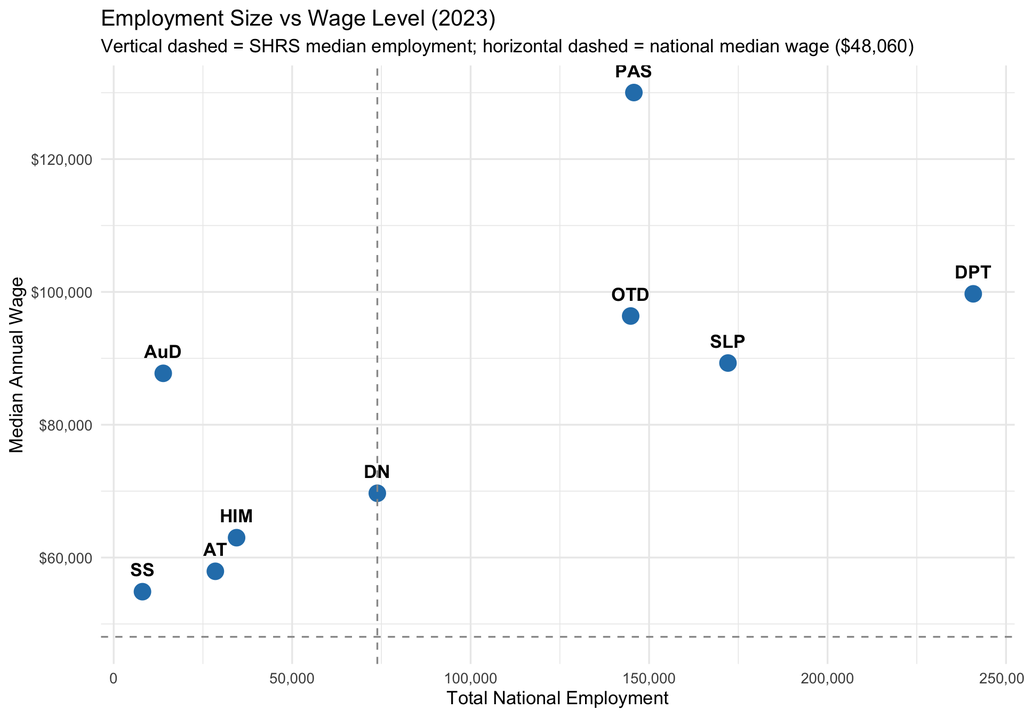

```r
shrs %>%
  ggplot(aes(x = tot_emp, y = a_median, label = shrs_program)) +
  geom_point(size = 5, color = COL_BLUE) +
  geom_text(vjust = -1.2, size = 4.5, fontface = "bold") +
  geom_vline(xintercept = median(shrs$tot_emp), linetype = "dashed",
             color = "gray60") +
  geom_hline(yintercept = bench_all$a_median, linetype = "dashed",
             color = "gray60") +
  scale_x_continuous(labels = comma) +
  scale_y_continuous(labels = dollar) +
  labs(
    title    = paste0("Employment Size vs Wage Level (", DATA_YEAR, ")"),
    subtitle = paste0("Vertical dashed = SHRS median employment; ",
                      "horizontal dashed = national median wage (",
                      dollar(bench_all$a_median), ")"),
    x = "Total National Employment", y = "Median Annual Wage"
  ) +
  theme_minimal(base_size = 13)
```

## 4.2 Ranking Among All Healthcare Occupations — Wages

```r
hc_detailed <- oews %>%
  filter(str_starts(occ_code, "29-"),
         occ_group == "detailed",
         !is.na(a_median)) %>%
  arrange(desc(a_median)) %>%
  mutate(
    wage_rank   = row_number(),
    n_hc_occs   = n(),
    wage_pctile = round((1 - wage_rank / n_hc_occs) * 100, 1),
    is_shrs     = occ_code %in% soc_crosswalk$soc_code
  )

shrs_wage_ranks <- hc_detailed %>%
  filter(is_shrs) %>%
  left_join(soc_crosswalk, by = c("occ_code" = "soc_code")) %>%
  select(shrs_program, occ_title = occupation_title, a_median,
         wage_rank, n_hc_occs, wage_pctile)

shrs_wage_ranks %>%
  select(Program = shrs_program, Occupation = occ_title,
         `Median Wage` = a_median, `Rank (of HC)` = wage_rank,
         `Total HC Occs` = n_hc_occs, `Wage Percentile` = wage_pctile) %>%
  kable(format.args = list(big.mark = ",")) %>%
  kable_styling(bootstrap_options = c("striped", "hover"), full_width = FALSE)
```

| Program | Occupation | Median Wage | Rank (of HC) | Total HC Occs | Wage Percentile |
| --- | --- | --- | --- | --- | --- |
| PAS | Physician Assistants | 130,020 | 13 | 56 | 76.8 |
| DPT | Physical Therapists | 99,710 | 18 | 56 | 67.9 |
| OTD | Occupational Therapists | 96,370 | 20 | 56 | 64.3 |
| SLP | Speech-Language Pathologists | 89,290 | 23 | 56 | 58.9 |
| AuD | Audiologists | 87,740 | 24 | 56 | 57.1 |
| DN | Dietitians and Nutritionists | 69,680 | 34 | 56 | 39.3 |
| HIM | Health Information Technologists and Medical Registrars | 62,990 | 38 | 56 | 32.1 |
| AT | Athletic Trainers | 57,930 | 44 | 56 | 21.4 |
| SS | Exercise Physiologists | 54,860 | 46 | 56 | 17.9 |

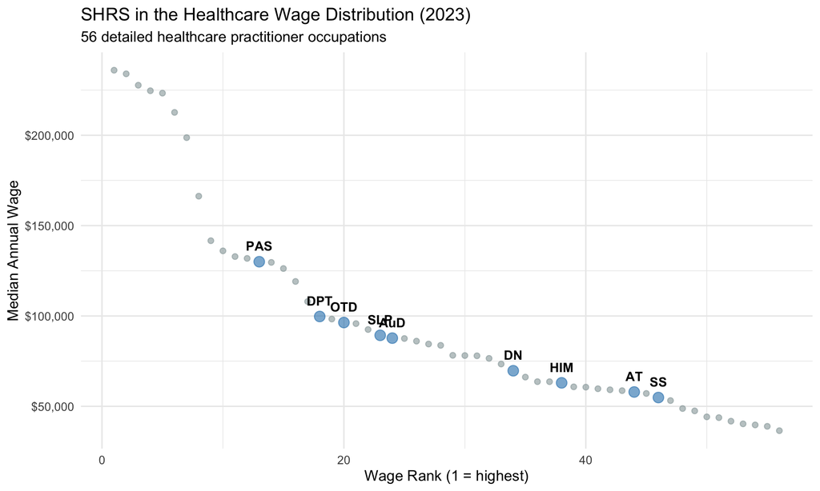

```r
hc_detailed %>%
  ggplot(aes(x = wage_rank, y = a_median)) +
  geom_point(aes(color = is_shrs, size = is_shrs), alpha = 0.6) +
  geom_text(
    data = hc_detailed %>% filter(is_shrs) %>%
      left_join(soc_crosswalk, by = c("occ_code" = "soc_code")),
    aes(label = shrs_program), vjust = -1.2, size = 4, fontface = "bold",
    color = "black"
  ) +
  scale_color_manual(values = c("FALSE" = COL_GRAY, "TRUE" = COL_BLUE)) +
  scale_size_manual(values = c("FALSE" = 2, "TRUE" = 4)) +
  scale_y_continuous(labels = dollar) +
  labs(
    title    = paste0("SHRS in the Healthcare Wage Distribution (", DATA_YEAR, ")"),
    subtitle = paste0(nrow(hc_detailed), " detailed healthcare practitioner occupations"),
    x = "Wage Rank (1 = highest)", y = "Median Annual Wage"
  ) +
  theme_minimal(base_size = 13) +
  theme(legend.position = "none")
```

## 4.3 Ranking Among HC Occupations — Employment

```r
hc_emp_ranked <- oews %>%
  filter(str_starts(occ_code, "29-"),
         occ_group == "detailed",
         !is.na(tot_emp)) %>%
  arrange(desc(tot_emp)) %>%
  mutate(
    emp_rank   = row_number(),
    n_hc_occs  = n(),
    emp_pctile = round((1 - emp_rank / n_hc_occs) * 100, 1),
    is_shrs    = occ_code %in% soc_crosswalk$soc_code
  )

shrs_emp_ranks <- hc_emp_ranked %>%
  filter(is_shrs) %>%
  left_join(soc_crosswalk, by = c("occ_code" = "soc_code")) %>%
  select(shrs_program, occ_title = occupation_title, tot_emp,
         emp_rank, n_hc_occs, emp_pctile)

shrs_emp_ranks %>%
  select(Program = shrs_program, Occupation = occ_title,
         `Total Emp` = tot_emp, `Rank (of HC)` = emp_rank,
         `Total HC Occs` = n_hc_occs, `Emp Percentile` = emp_pctile) %>%
  kable(format.args = list(big.mark = ",")) %>%
  kable_styling(bootstrap_options = c("striped", "hover"), full_width = FALSE)
```

| Program | Occupation | Total Emp | Rank (of HC) | Total HC Occs | Emp Percentile |
| --- | --- | --- | --- | --- | --- |
| DPT | Physical Therapists | 240,820 | 8 | 71 | 88.7 |
| SLP | Speech-Language Pathologists | 172,100 | 12 | 71 | 83.1 |
| PAS | Physician Assistants | 145,740 | 15 | 71 | 78.9 |
| OTD | Occupational Therapists | 144,840 | 16 | 71 | 77.5 |
| DN | Dietitians and Nutritionists | 73,860 | 27 | 71 | 62.0 |
| HIM | Health Information Technologists and Medical Registrars | 34,430 | 38 | 71 | 46.5 |
| AT | Athletic Trainers | 28,480 | 42 | 71 | 40.8 |
| AuD | Audiologists | 13,880 | 54 | 71 | 23.9 |
| SS | Exercise Physiologists | 8,060 | 63 | 71 | 11.3 |

# 5 — Data Quality & Precision Assessment

Higher PRSE = less precise estimate. Color indicates data quality health: green (reliable), yellow (usable with caution), red (interpret carefully).

```r
precision <- shrs %>%
  select(shrs_program, tot_emp, emp_prse, a_mean, mean_prse) %>%
  mutate(
    emp_95ci_lower  = round(tot_emp * (1 - 1.96 * emp_prse / 100)),
    emp_95ci_upper  = round(tot_emp * (1 + 1.96 * emp_prse / 100)),
    wage_se         = a_mean * (mean_prse / 100),
    wage_95ci_lower = round(a_mean - 1.96 * wage_se),
    wage_95ci_upper = round(a_mean + 1.96 * wage_se),
    precision_flag  = case_when(
      emp_prse > 5 | mean_prse > 3 ~ "Low Precision",
      emp_prse > 2 | mean_prse > 1 ~ "Moderate",
      TRUE                          ~ "High Precision"
    )
  )

precision %>%
  select(Program = shrs_program, `Total Emp` = tot_emp,
         `Emp PRSE (%)` = emp_prse,
         `Emp 95% CI Lo` = emp_95ci_lower, `Emp 95% CI Hi` = emp_95ci_upper,
         `Mean Wage` = a_mean, `Wage PRSE (%)` = mean_prse,
         `Wage 95% CI Lo` = wage_95ci_lower, `Wage 95% CI Hi` = wage_95ci_upper,
         Flag = precision_flag) %>%
  kable(format.args = list(big.mark = ",")) %>%
  kable_styling(bootstrap_options = c("striped", "hover"), full_width = FALSE)
```

| Program | Total Emp | Emp PRSE (%) | Emp 95% CI Lo | Emp 95% CI Hi | Mean Wage | Wage PRSE (%) | Wage 95% CI Lo | Wage 95% CI Hi | Flag |
| --- | --- | --- | --- | --- | --- | --- | --- | --- | --- |
| DN | 73,860 | 1.9 | 71,109 | 76,611 | 71,280 | 1.2 | 69,603 | 72,957 | Moderate |
| PAS | 145,740 | 1.7 | 140,884 | 150,596 | 130,490 | 0.4 | 129,467 | 131,513 | High Precision |
| OTD | 144,840 | 1.1 | 141,717 | 147,963 | 96,790 | 0.4 | 96,031 | 97,549 | High Precision |
| DPT | 240,820 | 1.3 | 234,684 | 246,956 | 100,440 | 0.5 | 99,456 | 101,424 | High Precision |
| SLP | 172,100 | 1.1 | 168,390 | 175,810 | 92,630 | 0.4 | 91,904 | 93,356 | High Precision |
| SS | 8,060 | 5.6 | 7,175 | 8,945 | 57,050 | 1.7 | 55,149 | 58,951 | Low Precision |
| AuD | 13,880 | 4.4 | 12,683 | 15,077 | 92,620 | 1.7 | 89,534 | 95,706 | Moderate |
| HIM | 34,430 | 1.4 | 33,485 | 35,375 | 70,260 | 0.6 | 69,434 | 71,086 | High Precision |
| AT | 28,480 | 2.1 | 27,308 | 29,652 | 61,540 | 0.5 | 60,937 | 62,143 | Moderate |

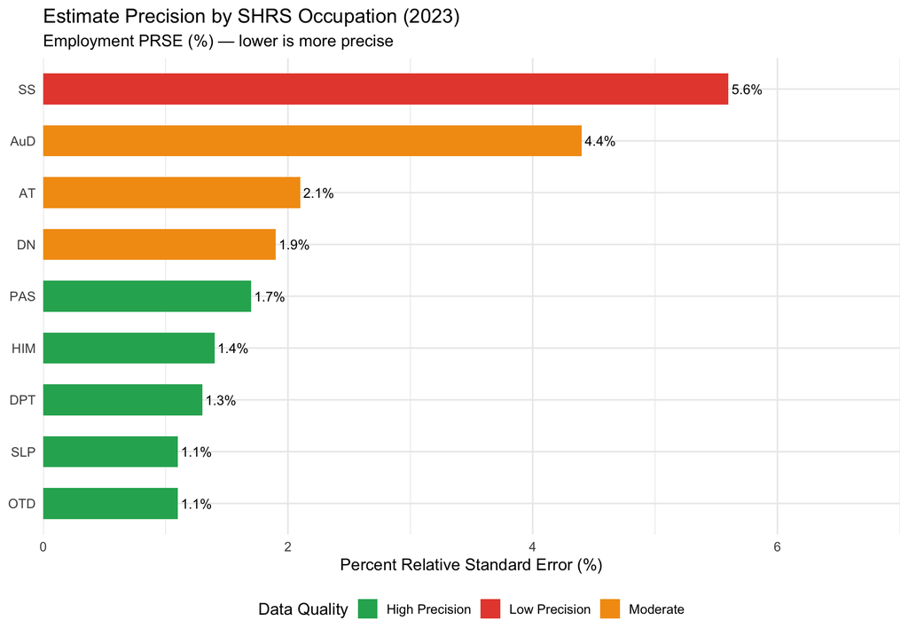

```r
precision %>%
  ggplot(aes(x = reorder(shrs_program, emp_prse), y = emp_prse,
             fill = precision_flag)) +
  geom_col(width = 0.6) +
  geom_text(aes(label = paste0(emp_prse, "%")), hjust = -0.1, size = 3.8) +
  coord_flip() +
  scale_fill_manual(values = precision_colors, name = "Data Quality") +
  scale_y_continuous(expand = expansion(mult = c(0, 0.25))) +
  labs(
    title    = paste0("Estimate Precision by SHRS Occupation (", DATA_YEAR, ")"),
    subtitle = "Employment PRSE (%) \u2014 lower is more precise",
    x = NULL, y = "Percent Relative Standard Error (%)"
  ) +
  theme_minimal(base_size = 13) +
  theme(legend.position = "bottom")
```

# 6 — Market Health Snapshot

Single-view health assessment for each SHRS program based on this year’s OEWS data. Each dimension is scored and colored.

```r
market_health <- shrs %>%
  mutate(
    # Wage health: premium over national median
    wage_premium_pct = round((a_median / bench_all$a_median - 1) * 100, 1),
    wage_health = case_when(
      a_median >= bench_hc$a_median  ~ "Strong",
      a_median >= bench_all$a_median ~ "Moderate",
      TRUE                           ~ "Weak"
    ),
    # Market size health: employment volume
    emp_health = case_when(
      tot_emp >= 100000 ~ "Strong",
      tot_emp >= 25000  ~ "Moderate",
      TRUE              ~ "Weak"
    ),
    # Data quality health: PRSE
    data_health = case_when(
      emp_prse <= 2 & mean_prse <= 1 ~ "Strong",
      emp_prse <= 5 & mean_prse <= 3 ~ "Moderate",
      TRUE                           ~ "Weak"
    ),
    # HC percentile ranks (from earlier computations)
    wage_pctile_hc = shrs_wage_ranks$wage_pctile[
      match(shrs_program, shrs_wage_ranks$shrs_program)],
    emp_pctile_hc = shrs_emp_ranks$emp_pctile[
      match(shrs_program, shrs_emp_ranks$shrs_program)]
  )

market_health %>%
  select(Program = shrs_program, Dept = shrs_dept, Degree = pitt_degree,
         `Tot Emp` = tot_emp, `Emp Health` = emp_health,
         `Median Wage` = a_median, `Wage Prem (%)` = wage_premium_pct,
         `Wage Health` = wage_health,
         `HC Wage %ile` = wage_pctile_hc, `HC Emp %ile` = emp_pctile_hc,
         `Data Quality` = data_health) %>%
  kable(format.args = list(big.mark = ",")) %>%
  kable_styling(bootstrap_options = c("striped", "hover"), full_width = FALSE)
```

| Program | Dept | Degree | Tot Emp | Emp Health | Median Wage | Wage Prem (%) | Wage Health | HC Wage %ile | HC Emp %ile | Data Quality |
| --- | --- | --- | --- | --- | --- | --- | --- | --- | --- | --- |
| DN | SMN | Master’s | 73,860 | Moderate | 69,680 | 45.0 | Moderate | 39.3 | 62.0 | Moderate |
| PAS | PAS | Master’s | 145,740 | Strong | 130,020 | 170.5 | Strong | 76.8 | 78.9 | Strong |
| OTD | OT | Doctoral | 144,840 | Strong | 96,370 | 100.5 | Strong | 64.3 | 77.5 | Strong |
| DPT | PT | Doctoral | 240,820 | Strong | 99,710 | 107.5 | Strong | 67.9 | 88.7 | Strong |
| SLP | CSD | Master’s | 172,100 | Strong | 89,290 | 85.8 | Strong | 58.9 | 83.1 | Strong |
| SS | SMN | Master’s | 8,060 | Weak | 54,860 | 14.1 | Moderate | 17.9 | 11.3 | Weak |
| AuD | CSD | Doctoral | 13,880 | Weak | 87,740 | 82.6 | Strong | 57.1 | 23.9 | Moderate |
| HIM | HIM | Master’s | 34,430 | Moderate | 62,990 | 31.1 | Moderate | 32.1 | 46.5 | Strong |
| AT | SMN | Master’s | 28,480 | Moderate | 57,930 | 20.5 | Moderate | 21.4 | 40.8 | Moderate |

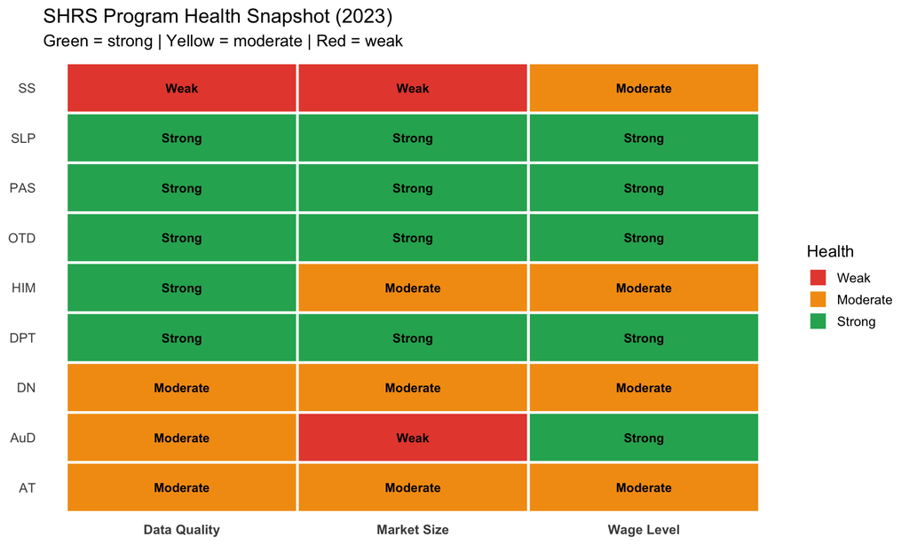

```r
health_long <- market_health %>%
  select(shrs_program, `Market Size` = emp_health,
         `Wage Level` = wage_health, `Data Quality` = data_health) %>%
  pivot_longer(-shrs_program, names_to = "dimension", values_to = "health")

health_long %>%
  mutate(health = factor(health, levels = c("Weak", "Moderate", "Strong"))) %>%
  ggplot(aes(x = dimension, y = shrs_program, fill = health)) +
  geom_tile(color = "white", linewidth = 1) +
  geom_text(aes(label = health), size = 3.5, fontface = "bold") +
  scale_fill_manual(values = health_colors, name = "Health") +
  labs(
    title    = paste0("SHRS Program Health Snapshot (", DATA_YEAR, ")"),
    subtitle = "Green = strong | Yellow = moderate | Red = weak",
    x = NULL, y = NULL
  ) +
  theme_minimal(base_size = 13) +
  theme(panel.grid = element_blank(),
        axis.text.x = element_text(face = "bold"))
```

# 7 — Output Registry

All named output objects produced by this analysis, stored and labeled for downstream aggregation or further manipulation.

```r
# ══════════════════════════════════════════════════════════════════════════════
# OUTPUT REGISTRY
# Every key object available after knitting / sourcing this file.
# ══════════════════════════════════════════════════════════════════════════════
#
# ── A. Core data ──
#   oews             Full cleaned OEWS dataset (all occupations, all groups)
#   shrs             Filtered to 9 SHRS programs with crosswalk fields
#   bench_all        All-Occupations benchmark row (1 row)
#   bench_hc         Healthcare Practitioners benchmark row (1 row)
#   soc_crosswalk    SOC code -> SHRS program mapping table (9 rows)
#
# ── B. Employment analysis ──
#   emp_summary      Employment levels + share of all occ / HC sector
#                    (11 rows: 9 SHRS + 2 benchmarks)
#
# ── C. Wage analysis ──
#   wage_summary     Full wage distribution (P10-P90, mean, IQR, skew)
#                    per program + benchmarks
#   wage_premium     Wage premium vs national median with 95% CI + health flag
#
# ── D. Rankings ──
#   shrs_wage_ranks  SHRS programs ranked among all HC occupations by wage
#   shrs_emp_ranks   SHRS programs ranked among all HC occupations by employment
#   hc_detailed      Full HC occupation ranking by wage (for context)
#   hc_emp_ranked    Full HC occupation ranking by employment (for context)
#
# ── E. Data quality ──
#   precision        PRSE, 95% CIs, and precision flags per program
#
# ── F. Health assessment ──
#   market_health    Per-program health flags + HC percentiles
#   health_long      Long-format health flags (for tile visualization)
#
# ── G. Aggregation-ready summary ──
#   output_year_summary   One row per program, designed to bind_rows() across years
# ══════════════════════════════════════════════════════════════════════════════

output_year_summary <- shrs %>%
  select(year, shrs_program, shrs_dept, pitt_degree, occ_code, occ_title,
         tot_emp, emp_prse, a_mean, a_median,
         a_pct10, a_pct25, a_pct75, a_pct90,
         h_mean, h_median, mean_prse) %>%
  mutate(
    # Benchmarks for this year
    bench_all_emp    = bench_all$tot_emp,
    bench_all_median = bench_all$a_median,
    bench_hc_emp     = bench_hc$tot_emp,
    bench_hc_median  = bench_hc$a_median,
    # Derived metrics
    iqr                 = a_pct75 - a_pct25,
    wage_spread_90_10   = a_pct90 - a_pct10,
    wage_premium_vs_all = round((a_median / bench_all$a_median - 1) * 100, 1),
    wage_premium_vs_hc  = round((a_median / bench_hc$a_median - 1) * 100, 1),
    pct_of_all_emp      = round(tot_emp / bench_all$tot_emp * 100, 4),
    pct_of_hc_emp       = round(tot_emp / bench_hc$tot_emp * 100, 3),
    # Health flags
    wage_health = case_when(
      a_median >= bench_hc$a_median  ~ "Strong",
      a_median >= bench_all$a_median ~ "Moderate",
      TRUE                           ~ "Weak"
    ),
    emp_health = case_when(
      tot_emp >= 100000 ~ "Strong",
      tot_emp >= 25000  ~ "Moderate",
      TRUE              ~ "Weak"
    ),
    data_health = case_when(
      emp_prse <= 2 & mean_prse <= 1 ~ "Strong",
      emp_prse <= 5 & mean_prse <= 3 ~ "Moderate",
      TRUE                           ~ "Weak"
    ),
    # HC percentile ranks
    wage_pctile_hc = shrs_wage_ranks$wage_pctile[
      match(shrs_program, shrs_wage_ranks$shrs_program)],
    emp_pctile_hc = shrs_emp_ranks$emp_pctile[
      match(shrs_program, shrs_emp_ranks$shrs_program)]
  )

cat("\n")
```

```r
cat("======================================================\n")
cat("  OUTPUT REGISTRY \u2014 ", DATA_YEAR, "\n")
```

```
##   OUTPUT REGISTRY —  2023
```

```r
cat("======================================================\n")
cat("  oews               :", nrow(oews), "rows x", ncol(oews), "cols\n")
```

```
##   oews               : 1403 rows x 15 cols
```

```r
cat("  shrs               :", nrow(shrs), "rows x", ncol(shrs), "cols\n")
```

```
##   shrs               : 9 rows x 17 cols
```

```r
cat("  emp_summary        :", nrow(emp_summary), "rows\n")
```

```
##   emp_summary        : 11 rows
```

```r
cat("  wage_summary       :", nrow(wage_summary), "rows\n")
```

```
##   wage_summary       : 11 rows
```

```r
cat("  wage_premium       :", nrow(wage_premium), "rows\n")
```

```
##   wage_premium       : 9 rows
```

```r
cat("  shrs_wage_ranks    :", nrow(shrs_wage_ranks), "rows\n")
```

```
##   shrs_wage_ranks    : 9 rows
```

```r
cat("  shrs_emp_ranks     :", nrow(shrs_emp_ranks), "rows\n")
```

```
##   shrs_emp_ranks     : 9 rows
```

```r
cat("  precision          :", nrow(precision), "rows\n")
```

```
##   precision          : 9 rows
```

```r
cat("  market_health      :", nrow(market_health), "rows\n")
```

```
##   market_health      : 9 rows
```

```r
cat("  output_year_summary:", nrow(output_year_summary), "rows x",
    ncol(output_year_summary), "cols\n")
```

```
##   output_year_summary: 9 rows x 32 cols
```

```r
cat("======================================================\n")
```

### Aggregation-Ready Summary Table

```r
output_year_summary %>%
  select(Year = year, Program = shrs_program, Dept = shrs_dept,
         `Total Emp` = tot_emp, `Emp PRSE` = emp_prse,
         `Median Wage` = a_median, `Mean Wage` = a_mean,
         IQR = iqr,
         `Prem vs All (%)` = wage_premium_vs_all,
         `Prem vs HC (%)` = wage_premium_vs_hc,
         `Wage Health` = wage_health,
         `Emp Health` = emp_health,
         `Data Quality` = data_health) %>%
  kable(format.args = list(big.mark = ",")) %>%
  kable_styling(bootstrap_options = c("striped", "hover"), full_width = FALSE)
```

| Year | Program | Dept | Total Emp | Emp PRSE | Median Wage | Mean Wage | IQR | Prem vs All (%) | Prem vs HC (%) | Wage Health | Emp Health | Data Quality |
| --- | --- | --- | --- | --- | --- | --- | --- | --- | --- | --- | --- | --- |
| 2,023 | DN | SMN | 73,860 | 1.9 | 69,680 | 71,280 | 23,570 | 45.0 | -13.8 | Moderate | Moderate | Moderate |
| 2,023 | PAS | PAS | 145,740 | 1.7 | 130,020 | 130,490 | 43,620 | 170.5 | 60.9 | Strong | Strong | Strong |
| 2,023 | OTD | OT | 144,840 | 1.1 | 96,370 | 96,790 | 30,190 | 100.5 | 19.2 | Strong | Strong | Strong |
| 2,023 | DPT | PT | 240,820 | 1.3 | 99,710 | 100,440 | 31,660 | 107.5 | 23.4 | Strong | Strong | Strong |
| 2,023 | SLP | CSD | 172,100 | 1.1 | 89,290 | 92,630 | 36,570 | 85.8 | 10.5 | Strong | Strong | Strong |
| 2,023 | SS | SMN | 8,060 | 5.6 | 54,860 | 57,050 | 18,240 | 14.1 | -32.1 | Moderate | Weak | Weak |
| 2,023 | AuD | CSD | 13,880 | 4.4 | 87,740 | 92,620 | 31,040 | 82.6 | 8.6 | Strong | Weak | Moderate |
| 2,023 | HIM | HIM | 34,430 | 1.4 | 62,990 | 70,260 | 40,370 | 31.1 | -22.1 | Moderate | Moderate | Strong |
| 2,023 | AT | SMN | 28,480 | 2.1 | 57,930 | 61,540 | 16,830 | 20.5 | -28.3 | Moderate | Moderate | Moderate |

```r
# ── Uncomment to save this year's summary as CSV for aggregation ──
# write_csv(output_year_summary,
#           paste0("shrs_oews_summary_", DATA_YEAR, ".csv"))
```

# Appendix: Data Source & Methodology

**Source**: Bureau of Labor Statistics, Occupational Employment and Wage Statistics (OEWS) Survey, 2023 national estimates.

**Color system**:

| Color | Usage | Meaning |
| --- | --- | --- |
| Green | Health performance | Strong / above HC benchmark |
| Yellow | Health performance | Moderate / above national but below HC |
| Red | Health performance | Weak / below national benchmark |
| Blue | Statistical visuals | Descriptive data (distributions, rankings, comparisons) |
| Gray | Supporting elements | Non-SHRS reference points, whiskers, benchmarks |

**Health thresholds**:

[output not shown]

**Benchmarks**:

- All Occupations (00-0000): 151,853,870 employed, median $48,060
- Healthcare Practitioners & Technical (29-0000): 9,284,210 employed, median $80,820